# Multivariate Analysis - pt.2

# 5장. 모집단 평균벡터에 관한 추론

## 모평균벡터에 대한 Hotelling T제곱 검정 - 예제1

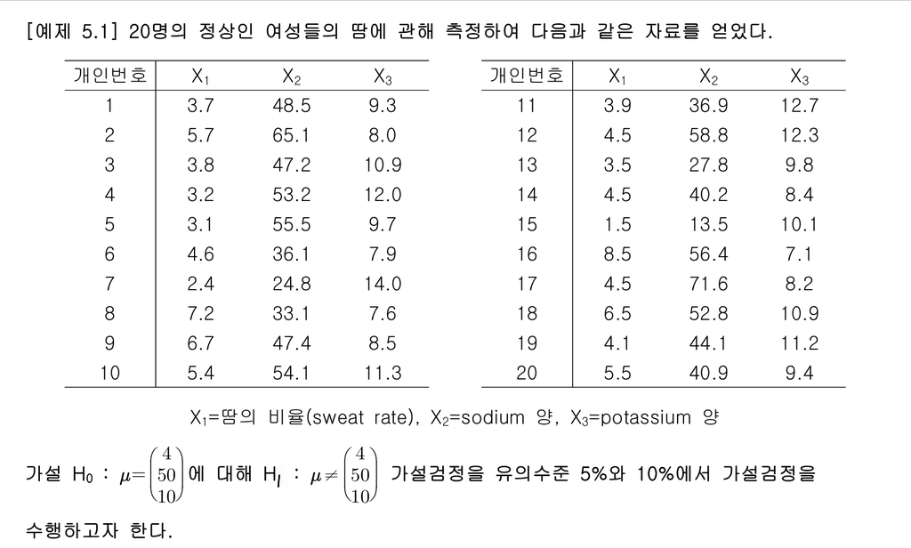

### Loading data

```r
data <- read.csv("/Users/jaeyonglee/Documents/College/Bachelor/uniwise/MVA/R/data/ch5/sweat.csv", header=TRUE, skip=5)
sweat <- data[,-1]  # 1열이 그냥 인덱스여서 얘를 빼주자
sweat
```

| X1 | X2 | X3 |
| --- | --- | --- |
| 3.7 | 48.5 | 9.3 |
| 5.7 | 65.1 | 8.0 |
| 3.8 | 47.2 | 10.9 |
| 3.2 | 53.2 | 12.0 |
| 3.1 | 55.5 | 9.7 |
| 4.6 | 36.1 | 7.9 |
| 2.4 | 24.8 | 14.0 |
| 7.2 | 33.1 | 7.6 |
| 6.7 | 47.4 | 8.5 |
| 5.4 | 54.1 | 11.3 |

[output cut: 10 more lines]

```r
n <- dim(sweat)[1]  # 표본의 수
p <- dim(sweat)[2]  # 변수의 수
```

### 표본의 수

```r
n <- dim(sweat)[1]
n
```

```
[1] 20
```

### 변수의 수

```r
p <- dim(sweat)[2]
p
```

```
[1] 3
```

### 3D 산점도

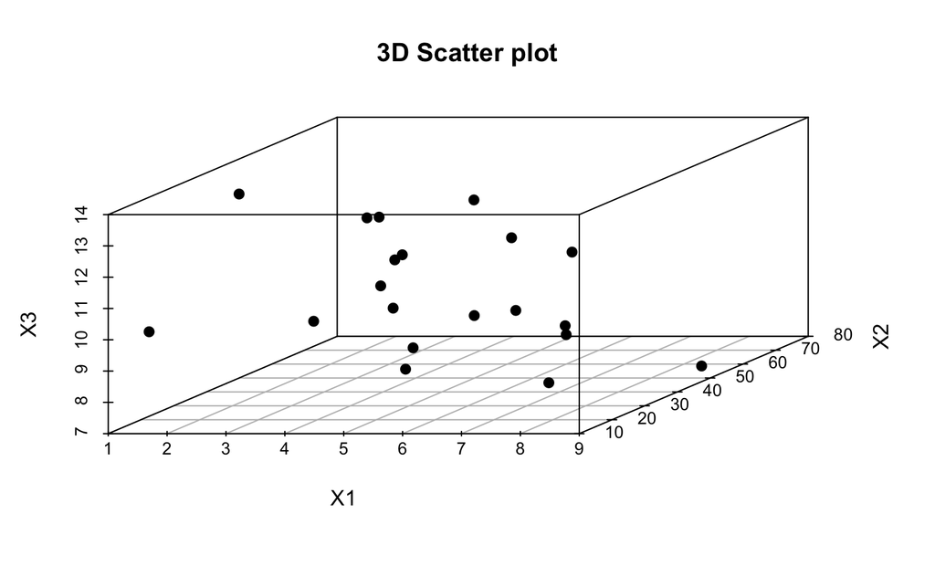

```r
library(scatterplot3d)

scatterplot3d(sweat, main="3D Scatter plot", pch=19)
```

### 검정 모평균벡터

```r
mu0 <- c(4, 50, 10)
mu0
```

```
[1]  4 50 10
```

### 평균벡터

```r
m <- colMeans(sweat)
m
```

```
    X1     X2     X3
 4.640 45.400  9.965
```

### 표본공분산행렬

```r
S <- cov(sweat)
S
```

```
          X1       X2        X3
X1  2.879368  10.0100 -1.809053
X2 10.010000 199.7884 -5.640000
X3 -1.809053  -5.6400  3.627658
```

### 표본공분산행렬 역행렬

```r
S.inv <- solve(S)
S.inv
```

```
            X1           X2           X3
X1  0.58615531 -0.022085719  0.257968742
X2 -0.02208572  0.006067227 -0.001580929
X3  0.25796874 -0.001580929  0.401846765
```

### Hotelling T제곱 검정통계량

```r
T2 <- n*(m-mu0) %*% S.inv %*% (m-mu0)
T2
```

```
         [,1]
[1,] 9.738773
```

### 유의수준 5%에서의 기각값

```r
alpha = 0.05
((n-1)*p)/(n-p)*qf(1-alpha, p, n-p)  # 누적확률이 1-alpha인 지점이 기각값이다
```

```
[1] 10.7186
```

#### 유의수준 5%에서 검정통계량이 기각역에 없으므로 귀무가설을 기각하지 못한다.

### 유의수준 10%에서의 기각값

```r
alpha <- 0.10
((n-1)*p)/(n-p)*qf(1-alpha, p, n-p)
```

```
[1] 8.172573
```

#### 유의수준 10%에서 검정통계량이 기각역에 있으므로 귀무가설을 기각한다.

### 유의확률 (p-value)

```r
pf((n-p)/((n-1)*p)*T2, p, n-p, lower.tail=FALSE)  # P(F ≥ 관측값)을 구하는거라 lower tail 필요없음
```

```
           [,1]
[1,] 0.06492834
```

#### 유의수준 5%에서는 귀무가설을 기각못하고, 유의수준 10%에서는 귀무가설을 기각할 수 있음을 볼 수 있다.

## 모평균벡터에 대한 Hotelling T제곱 검정 - 예제2

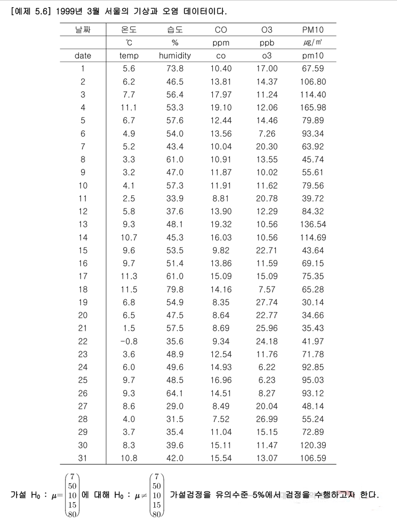

#### 여기서 모평균벡터의 원소들은 차례대로 온도, 습도, CO, O3, pm10이다.

### Loading data

```r
data <- read.table("/Users/jaeyonglee/Documents/College/Bachelor/uniwise/MVA/R/data/ch5/air_pollution.txt", header=TRUE, sep="\t", skip=4)
air <- data[,-1]  # 첫번째 변수가 날짜인데 필요가 없는듯 하다
air
```

| temp | humidity | co | o3 | pm10 |
| --- | --- | --- | --- | --- |
| 5.6 | 73.8 | 10.40 | 17.00 | 67.59 |
| 6.2 | 46.5 | 13.81 | 14.37 | 106.80 |
| 7.7 | 56.4 | 17.97 | 11.24 | 114.40 |
| 11.1 | 53.3 | 19.10 | 12.06 | 165.98 |
| 6.7 | 57.6 | 12.44 | 14.46 | 79.89 |
| 4.9 | 54.0 | 13.56 | 7.26 | 93.34 |
| 5.2 | 43.4 | 10.04 | 20.30 | 63.92 |
| 3.3 | 61.0 | 10.91 | 13.55 | 45.74 |
| 3.2 | 47.0 | 11.87 | 10.02 | 55.61 |
| 4.1 | 57.3 | 11.91 | 11.62 | 79.56 |

[output cut: 21 more lines]

### 표본의 수

```r
n <- dim(air)[1]
n
```

```
[1] 31
```

### 변수의 수

```r
p <- dim(air)[2]
p
```

```
[1] 5
```

### 검정 모평균벡터

```r
mu0 <- c(7, 50, 10, 15, 80)
mu0
```

```
[1]  7 50 10 15 80
```

### 평균벡터

```r
m <- colMeans(air)
m
```

```
     temp  humidity        co        o3      pm10
 6.658065 49.838710 12.730968 14.931613 77.411290
```

### 표본공분산행렬

```r
S <- cov(air)
round(S, 3)  # 소수 셋째 점 까지만
```

```
           temp humidity      co       o3     pm10
temp     10.304   10.879   6.572   -8.212   55.059
humidity 10.879  135.238   8.651  -22.258   16.422
co        6.572    8.651  10.899  -16.324   97.067
o3       -8.212  -22.258 -16.324   39.412 -133.763
pm10     55.059   16.422  97.067 -133.763 1059.581
```

### 표본공분산행렬 역행렬

```r
S.inv <- solve(S)
round(S.inv, 3)
```

```
           temp humidity     co     o3   pm10
temp      0.173   -0.009 -0.153 -0.026  0.002
humidity -0.009    0.010 -0.018  0.005  0.003
co       -0.153   -0.018  0.993  0.155 -0.063
o3       -0.026    0.005  0.155  0.075 -0.003
pm10      0.002    0.003 -0.063 -0.003  0.006
```

### Hotelling T제곱 검정통계량

```r
T2 <- n*(m-mu0) %*% S.inv %*% (m-mu0)
T2
```

```
         [,1]
[1,] 266.8351
```

### 유의수준 5%에서의 기각값

```r
alpha <- 0.05

((n-1)*p)/(n-p)*qf(1-alpha, p, n-p)
```

```
[1] 14.92379
```

#### 유의수준 5%에서 검정통계량이 기각역에 있으므로 귀무가설을 기각한다.

### 유의확률

```r
pf((n-p)/((n-1)*p)*T2, p, n-p, lower.tail=FALSE)
```

```
             [,1]
[1,] 4.005047e-12
```

#### 유의확률이 유의수준 0.05보다 작으므로 귀무가설을 기각한다.

### ICSNP패키지를 활용한 검정

#### Hotelling’s one sample T2-test: T2 ~ 카이제곱(df=p) (근사인듯?)

```r
library(ICSNP)

HotellingsT2(air, mu=c(7, 50, 10, 15, 80), test="chi")  # mu는 검정하고자 하는 모평균, test는 검정법
```

```
    Hotelling's one sample T2-test

data:  air
T.2 = 266.84, df = 5, p-value < 2.2e-16
alternative hypothesis: true location is not equal to c(7,50,10,15,80)
```

#### 여기서 구해진 T.2는 그냥 T2이다.

#### 유의확률이 유의수준 0.05보다 작으므로 귀무가설을 기각한다.

#### Hotelling’s one sample T2-test: (n-p)/((n-1)*p)*T2 ~ F(p,n-p)

```r
HotellingsT2(air, mu=c(7, 50, 10, 15, 80), test="f")
```

```
    Hotelling's one sample T2-test

data:  air
T.2 = 46.251, df1 = 5, df2 = 26, p-value = 4.005e-12
alternative hypothesis: true location is not equal to c(7,50,10,15,80)
```

#### 여기서 구해진 T.2는 (n-p)/((n-1)*p)*T2이다.

#### 유의확률이 유의수준 0.05보다 작으므로 귀무가설을 기각한다.

## 독립인 두 집단의 모평균벡터에 대한 Hotelling T제곱 검정 (두 집단의 공분산행렬이 같다)

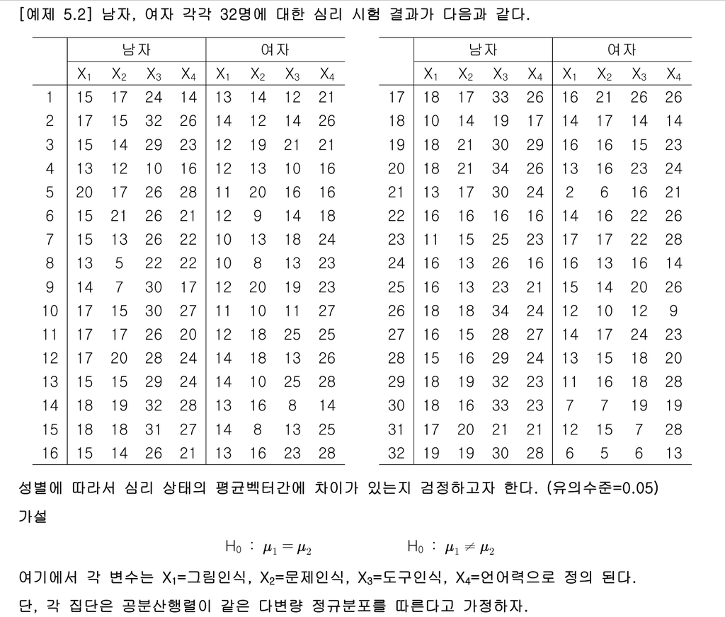

### Loading data

```r
data <- read.table("/Users/jaeyonglee/Documents/College/Bachelor/uniwise/MVA/R/data/ch5/psy_test.txt", header=TRUE, skip=6, sep="\t")
data
```

| Gender | X1 | X2 | X3 | X4 |
| --- | --- | --- | --- | --- |
| 1 | 15 | 17 | 24 | 14 |
| 1 | 17 | 15 | 32 | 26 |
| 1 | 15 | 14 | 29 | 23 |
| 1 | 13 | 12 | 10 | 16 |
| 1 | 20 | 17 | 26 | 28 |
| 1 | 15 | 21 | 26 | 21 |
| 1 | 15 | 13 | 26 | 22 |
| 1 | 13 | 5 | 22 | 22 |
| 1 | 14 | 7 | 30 | 17 |
| 1 | 17 | 15 | 30 | 27 |

[output cut: 54 more lines]

### Data preprocessing

```r
data$Gender <- factor(data$Gender, labels=c("남자","여자"))  # 0,1인 이진형 변수에 레이블 씌우기
data
```

| Gender | X1 | X2 | X3 | X4 |
| --- | --- | --- | --- | --- |
| 남자 | 15 | 17 | 24 | 14 |
| 남자 | 17 | 15 | 32 | 26 |
| 남자 | 15 | 14 | 29 | 23 |
| 남자 | 13 | 12 | 10 | 16 |
| 남자 | 20 | 17 | 26 | 28 |
| 남자 | 15 | 21 | 26 | 21 |
| 남자 | 15 | 13 | 26 | 22 |
| 남자 | 13 | 5 | 22 | 22 |
| 남자 | 14 | 7 | 30 | 17 |
| 남자 | 17 | 15 | 30 | 27 |

[output cut: 54 more lines]

#### 데이터를 성별에 따라 두 집단으로 나누기

```r
attach(data)
male <- data[Gender=="남자", -1]  # 성별 변수는 이제 필요가 없으므로 빼준다
male
```

[output not shown]

```r
female <- data[Gender=="여자", -1]
female
```

[output not shown]

```r
detach(data)
```

### 남자 표본의 수

```r
n1 <- dim(male)[1]
n1
```

```
[1] 32
```

### 여자 표본의 수

```r
n2 <- dim(female)[1]
n2
```

```
[1] 32
```

### 변수의 수

```r
p <- dim(male)[2]  # 어차피 두 집단의 변수의 수는 같음
p
```

```
[1] 4
```

### 남자 평균벡터

```r
m1 <- colMeans(male)
m1
```

```
      X1       X2       X3       X4
15.96875 15.90625 27.18750 22.75000
```

### 여자 평균벡터

```r
m2 <- colMeans(female)
m2
```

```
      X1       X2       X3       X4
12.34375 13.90625 16.65625 21.93750
```

### 남자 표본공분산행렬

```r
S1 <- cov(male)
S1
```

```
         X1        X2        X3        X4
X1 5.192540  4.545363  6.522177  5.250000
X2 4.545363 13.184476  6.760081  6.266129
X3 6.522177  6.760081 28.673387 14.467742
X4 5.250000  6.266129 14.467742 16.645161
```

### 여자 표본공분산행렬

```r
S2 <- cov(female)
S2
```

```
         X1        X2        X3        X4
X1 9.136089  7.549395  4.863911  4.151210
X2 7.549395 18.603831 10.224798  5.445565
X3 4.863911 10.224798 30.039315 13.493952
X4 4.151210  5.445565 13.493952 27.995968
```

### 합동(공통)표본공분산행렬 (공분산이 같다는 가정이 됨)

```r
S.pl <- ((n1-1)*S1 + (n2-1)*S2)/(n1+n2-2)
S.pl
```

```
         X1        X2        X3        X4
X1 7.164315  6.047379  5.693044  4.700605
X2 6.047379 15.894153  8.492440  5.855847
X3 5.693044  8.492440 29.356351 13.980847
X4 4.700605  5.855847 13.980847 22.320565
```

### Hotelling T제곱 검정통계량

```r
T2 <- (m1-m2) %*% solve((1/n1 + 1/n2)*S.pl) %*% (m1-m2)  # R에서는 앞에 벡터가 전치가 아니여도 알아서 계산을 해주기 때문에 식처럼 굳이 따로 전치를 해줄 필요가 없다
T2
```

```
        [,1]
[1,] 97.6015
```

### 유의수준 5%에서의 기각값

```r
alpha <- 0.05

((n1+n2-2)*p)/(n1+n2-p-1)*qf(1-alpha, p, n1+n2-p-1)  # 누적확률이 1-alpha인 지점이 기각값임
```

```
[1] 10.62578
```

#### 유의수준 5%에서 검정통계량이 기각역에 있으므로 귀무가설을 기각한다. 즉, 남녀간 평균벡터차가 있다.

### 유의확률

```r
pf((n1+n2-p-1)/((n1+n2-2)*p)*T2, p, n1+n2-p-1, lower.tail=FALSE)
```

```
             [,1]
[1,] 1.464321e-11
```

#### 유의확률이 유의수준 0.05보다 작으므로 귀무가설을 기각한다. 즉, 남녀간 평균벡터차가 있다.

### ICSNP패키지를 활용한 검정

#### Hotelling’s two sample T2-test: T2 ~ 카이제곱(df=p)

```r
HotellingsT2(male, female, test="chi")
```

```
    Hotelling's two sample T2-test

data:  male and female
T.2 = 97.601, df = 4, p-value < 2.2e-16
alternative hypothesis: true location difference is not equal to c(0,0,0,0)
```

#### 여기서 구해진 T.2는 그냥 T2이다.

#### 유의확률이 유의수준 0.05보다 작으므로 귀무가설을 기각한다.

#### Hotelling’s two sample T2-test: T2 ~ F(p, n1+n2-p-1)

```r
HotellingsT2(male, female, test="f")  # mu에 따로 값을 안주면 자동으로 0으로 인식
```

```
    Hotelling's two sample T2-test

data:  male and female
T.2 = 23.22, df1 = 4, df2 = 59, p-value = 1.464e-11
alternative hypothesis: true location difference is not equal to c(0,0,0,0)
```

#### 여기서 구해진 T.2는 (n1+n2-p-1)/((n1+n2-2)*p)*T2이다.

#### 유의확률이 유의수준 0.05보다 작으므로 귀무가설을 기각한다.

### ICSNP의 HotellingsT2을 쓸 땐 데이터를 집단별로 직접 나누지 않아도 됨

```r
X <- as.matrix(data[,-1])  # 대신 집단변수 외 데이터는 matrix화 해줘야 함
G <- data[,1]
HotellingsT2(X~G, test="f")
```

```
    Hotelling's two sample T2-test

data:  X by G
T.2 = 23.22, df1 = 4, df2 = 59, p-value = 1.464e-11
alternative hypothesis: true location difference is not equal to c(0,0,0,0)
```

#### 유의확률이 유의수준 0.05보다 작으므로 귀무가설을 기각한다.

## 독립인 두 집단의 모평균벡터에 대한 Hotelling T제곱 검정 (두 집단의 공분산행렬이 다르다)

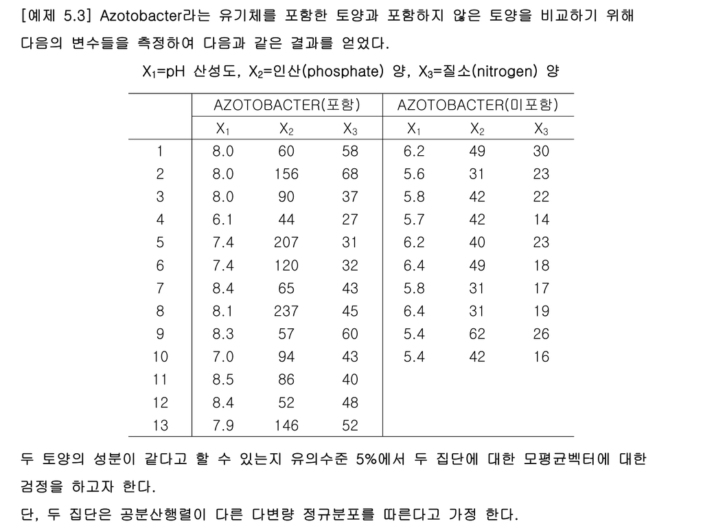

#### H0: mu1 = mu2 vs. H1: mu1 ≠ mu2 을 유의수준 5%에서 검정하라

#### (단, 각 집단은 공분산행렬이 다르다)

### Loading data

```r
data <- read.table("/Users/jaeyonglee/Documents/College/Bachelor/uniwise/MVA/R/data/ch5/Azotobacter.txt", header=TRUE, skip=5, sep="\t")
data
```

| AZO | X1 | X2 | X3 |
| --- | --- | --- | --- |
| 1 | 8.0 | 60 | 58 |
| 1 | 8.0 | 156 | 68 |
| 1 | 8.0 | 90 | 37 |
| 1 | 6.1 | 44 | 27 |
| 1 | 7.4 | 207 | 31 |
| 1 | 7.4 | 120 | 32 |
| 1 | 8.4 | 65 | 43 |
| 1 | 8.1 | 237 | 45 |
| 1 | 8.3 | 57 | 60 |
| 1 | 7.0 | 94 | 43 |

[output cut: 13 more lines]

### Data preprocessing

```r
data$AZO <- factor(data$AZO, labels=c("포함", "미포함"))  # 이진형 변수인 AZO에 레이블 씌우기
data
```

| AZO | X1 | X2 | X3 |
| --- | --- | --- | --- |
| 포함 | 8.0 | 60 | 58 |
| 포함 | 8.0 | 156 | 68 |
| 포함 | 8.0 | 90 | 37 |
| 포함 | 6.1 | 44 | 27 |
| 포함 | 7.4 | 207 | 31 |
| 포함 | 7.4 | 120 | 32 |
| 포함 | 8.4 | 65 | 43 |
| 포함 | 8.1 | 237 | 45 |
| 포함 | 8.3 | 57 | 60 |
| 포함 | 7.0 | 94 | 43 |

[output cut: 13 more lines]

#### 데이터를 두 집단(집단1, 집단2)으로 나누기

```r
attach(data)
inc <- data[AZO == "포함", -1]  # 집단 구분 변수는 더이상 필요 없으므로 뺴준다
inc
```

|  | X1 | X2 | X3 |
| --- | --- | --- | --- |
| 1 | 8.0 | 60 | 58 |
| 2 | 8.0 | 156 | 68 |
| 3 | 8.0 | 90 | 37 |
| 4 | 6.1 | 44 | 27 |
| 5 | 7.4 | 207 | 31 |
| 6 | 7.4 | 120 | 32 |
| 7 | 8.4 | 65 | 43 |
| 8 | 8.1 | 237 | 45 |
| 9 | 8.3 | 57 | 60 |
| 10 | 7.0 | 94 | 43 |

[output cut: 3 more lines]

```r
exc <- data[AZO == "미포함", -1]
exc
```

|  | X1 | X2 | X3 |
| --- | --- | --- | --- |
| 14 | 6.2 | 49 | 30 |
| 15 | 5.6 | 31 | 23 |
| 16 | 5.8 | 42 | 22 |
| 17 | 5.7 | 42 | 14 |
| 18 | 6.2 | 40 | 23 |
| 19 | 6.4 | 49 | 18 |
| 20 | 5.8 | 31 | 17 |
| 21 | 6.4 | 31 | 19 |
| 22 | 5.4 | 62 | 26 |
| 23 | 5.4 | 42 | 16 |

```r
detach(data)
```

### 집단1의 표본의 수

```r
n1 <- dim(inc)[1]
n1
```

```
[1] 13
```

### 집단2의 표본의 수

```r
n2 <- dim(exc)[1]
n2
```

```
[1] 10
```

### 변수의 수

```r
p <- dim(inc)[2]  # 어차피 두 집단의 변수의 수는 같음
p
```

```
[1] 3
```

### 집단1의 평균벡터

```r
m1 <- colMeans(inc)
m1
```

```
        X1         X2         X3
  7.807692 108.769231  44.923077
```

### 집단2의 평균벡터

```r
m2 <- colMeans(exc)
m2
```

```
   X1    X2    X3
 5.89 41.90 20.80
```

### 집단1의 표본공분산행렬

```r
S1 <- cov(inc)
S1
```

```
          X1          X2         X3
X1 0.4607692    1.176923   4.492308
X2 1.1769231 3776.358974 -17.352564
X3 4.4923077  -17.352564 147.243590
```

### 집단2의 표본공분산행렬

```r
S2 <- cov(exc)
S2
```

```
           X1         X2         X3
X1  0.1476667 -0.6788889  0.2088889
X2 -0.6788889 96.1000000 20.2000000
X3  0.2088889 20.2000000 24.1777778
```

### Hotelling T제곱 검정통계량

```r
T2 <- (m1-m2) %*% solve(S1/n1 + S2/n2) %*% (m1-m2)  # 전에도 언급했듯이 첫번째 벡터를 굳이 전치를 해줄 필요가 없음, R이 알아서 계산 해줌
T2
```

```
         [,1]
[1,] 96.81778
```

### 유의수준 5%에서의 기각값

```r
alpha <- 0.05

qchisq(1-alpha, p)  # 누적확률이 1-alpha인 지점이 기각값임
```

```
[1] 7.814728
```

#### 유의수준 5%에서 검정통계량이 기각역에 있으므로 귀무가설을 기각한다. 즉, 두 집단간 평균벡터에 차이가 있다.

### 유의확률 (p-value)

```r
pchisq(T2, p, lower.tail=FALSE)
```

```
             [,1]
[1,] 7.509685e-21
```

#### 유의확률이 유의수준 0.05보다 작으므로 귀무가설을 기각한다. 즉, 두 집단간 평균벡터에 차이가 있다.

## 짝지어진 두 집단의 모평균벡터에 대한 검정

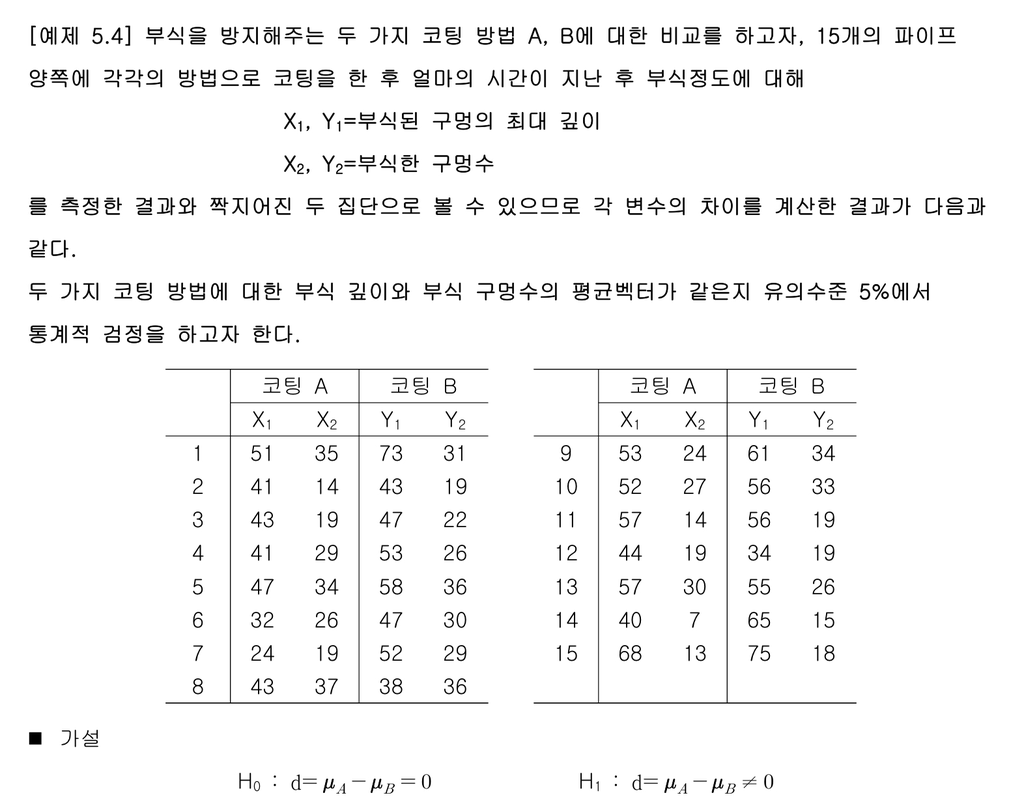

### Loading data

```r
pipe <- read.csv("/Users/jaeyonglee/Documents/College/Bachelor/uniwise/MVA/R/data/ch5/pipe.csv", header=TRUE, skip=5)
pipe
```

| X1 | X2 | Y1 | Y2 |
| --- | --- | --- | --- |
| 51 | 35 | 73 | 31 |
| 41 | 14 | 43 | 19 |
| 43 | 19 | 47 | 22 |
| 41 | 29 | 53 | 26 |
| 47 | 34 | 58 | 36 |
| 32 | 26 | 47 | 30 |
| 24 | 19 | 52 | 29 |
| 43 | 37 | 38 | 36 |
| 53 | 24 | 61 | 34 |
| 52 | 27 | 56 | 33 |

[output cut: 5 more lines]

### 변수차

```r
pipe.dif <- data.frame(D1 = pipe$X1 - pipe$Y1, D2 = pipe$X2 - pipe$Y2)
pipe.dif
```

| D1 | D2 |
| --- | --- |
| -22 | 4 |
| -2 | -5 |
| -4 | -3 |
| -12 | 3 |
| -11 | -2 |
| -15 | -4 |
| -28 | -10 |
| 5 | 1 |
| -8 | -10 |
| -4 | -6 |

[output cut: 5 more lines]

### 표본의 수

```r
n <- dim(pipe.dif)[1]
n
```

```
[1] 15
```

### 변수의 수

```r
p <- dim(pipe.dif)[2]
p
```

```
[1] 2
```

### 평균벡터

```r
m <- colMeans(pipe.dif)
m
```

```
       D1        D2
-8.000000 -3.066667
```

### 표본공분산행렬

```r
S <- cov(pipe.dif)
S
```

```
          D1       D2
D1 121.57143 17.07143
D2  17.07143 21.78095
```

### 표본공분산행렬 역행렬

```r
S.inv <- solve(S)
S.inv
```

```
             D1           D2
D1  0.009242894 -0.007244376
D2 -0.007244376  0.051589656
```

### Hotelling T제곱 검정통계량

```r
T2 <- n*m %*% S.inv %*% m
T2
```

```
        [,1]
[1,] 10.8189
```

### 유의수준 5%에서의 기각값

```r
alpha <- 0.05

((n-1)*p)/(n-p)*qf(1-alpha, p, n-p)
```

```
[1] 8.196602
```

#### 유의수준 5%에서 검정통계량이 기각역에 있으므로 귀무가설을 기각한다. 즉, 코팅방법에 따라 부식 깊이와 구멍개수의 평균벡터간 차이가 있다.

### 유의확률

```r
pf((n-p)/((n-1)*p)*T2, p, n-p, lower.tail=FALSE)
```

```
           [,1]
[1,] 0.02419613
```

#### 유의확률이 유의수준 0.05보다 작으므로 귀무가설을 기각한다. 즉, 코팅방법에 따라 부식 깊이와 구멍개수의 평균벡터간 차이가 있다.

### ICSNP패키지를 활용한 검정

#### Hotelling’s one sample T2-test: T2 ~ 카이제곱(p)

```r
HotellingsT2(pipe.dif, mu=c(0,0), test="chi")
```

```
    Hotelling's one sample T2-test

data:  pipe.dif
T.2 = 10.819, df = 2, p-value = 0.004474
alternative hypothesis: true location is not equal to c(0,0)
```

#### 여기서 T.2는 그냥 T2이다.

#### 유의확률이 유의수준 0.05보다 작으므로 귀무가설을 기각한다.

#### Hotelling’s one sample T2-test: (n-p)/((n-1)*p)*T2 ~ F(p, n-p)

```r
HotellingsT2(pipe.dif, mu=c(0,0), test="f")
```

```
    Hotelling's one sample T2-test

data:  pipe.dif
T.2 = 5.0231, df1 = 2, df2 = 13, p-value = 0.0242
alternative hypothesis: true location is not equal to c(0,0)
```

#### 여기서 T.2는 (n-p)/((n-1)*p)*T2이다.

#### 유의확률이 유의수준 0.05보다 작으므로 귀무가설을 기각한다.